# Tutorial RStudio | Primeiro Contato

Paulo S. P Silveira (paulo.silveira@fm.usp.br) Koichi Sameshima (koichi.sameshima@fm.usp.br) José O. Siqueira (jose.siqueira@fm.usp.br)

O RStudio é um ambiente que facilita o uso do R. Além do terminal R (chamado também de console, no qual pode dar comandos diretos) agrupa arquivos, disponibiliza janelas auxiliares e dá acesso à documentação do R.

RStudio roda em Linux, Macintosh e Windows sob R. Para que tudo funcione, o primeiro passo é instalá-los (primeiro R e, depois, o RStudio).

Para experimentar seu uso, vamos:

- criar um projeto no RStudio,
- ler um arquivo texto com dados e
- experimentarmos alguns comandos de estatística descritiva.

## Áreas da tela no RStudio

Ao entrar no RStudio, encontrará a uma tela como esta:

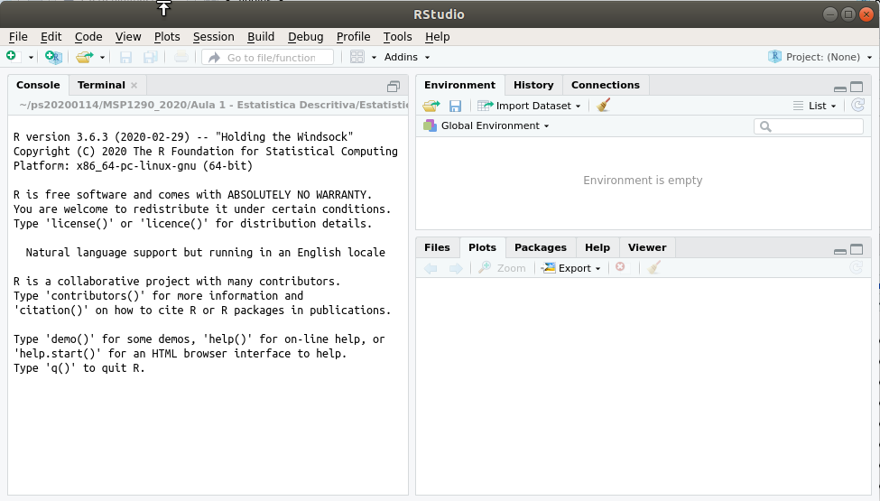

Reconheça os seguintes elementos:

- uma área com as abas *Console* e *Terminal*. Usaremos a *Console* sempre (o terminal serve para usos mais avançados e desnecessários para nosso contexto). A console permite que usemos comandos diretos em R (veremos adiante).
- uma área com as abas *Environment* (ambiente), *History* (histórico) e *Connections* (conexões). Usaremos principalmente o ambiente, onde as variáveis ativas aparecem (também as veremos em ação adiante).
- uma área com as abas *Files* (arquivos), *Plots* (gráficos), *Packages* (pacotes), *Help* (ajuda) e *Viewer* (visualizador). Os dois primeiros e a área de ajuda são os mais importantes para começar.

## Começando a usar a *Console*

É através da *Console* que usamos comandos para o R. Vamos experimentar algumas coisas simples, para começar.

O símbolo **>** é o *prompt* do R, indicando que está pronto para receber uma instrução qualquer. Por exemplo, podemos fazer uma conta digitando na *Console* (digite após o símbolo **>** e pressione [enter] ao final da linha):

```r
4+5
```

obtendo

```
[1] 9
```

A soma de quatro e cinco resulta em 9.

Podemos guardar os valores em **variáveis** (pressione [enter] ao final de cada linha):

```r
a <- 4
b <- 5
a + b
```

```
[1] 9
```

Dando nomes, **a** e **b** são variáveis que receberam (com o operador de atribuição, **<-**) os valores 4 e 5, respectivamente. Sua soma, **a + b** (**+** é o operador da adição), é 9. Podemos guardar este resultado em uma outra variável:

```r
soma <- a + b
```

e podemos ecoar o conteúdo da variável **soma**, simplemente escrevendo seu nome:

```r
soma
```

```
[1] 9
```

Observe que nomes de variáveis podem ter várias letras e números (desde que comece com letra). Não use letras acentuadas e tenha cuidado com a grafia porque o R distingue maiúsculas de minúsculas: **soma**, **Soma** e **SOMA** são variáveis diferentes, cada uma criada com conteúdo independente.

Nomes como soma_1, Soma_b, x ou A são, também, nomes válidos para variáveis. Crie variáveis com nomes que facilitem, para você, lembrar o tipo de conteúdo depositado nelas.

O resultado armazenado na variável **soma** pode ser usado:

```r
raiz <- sqrt(soma)
raiz
```

```
[1] 3
```

Neste exemplo, pela primeira vez, usamos uma função, **sqrt()**, que extrai a raiz quadrada (*square root*, em inglês) de **soma** e a armazena em outra variável, **raiz**. O R distingue variáveis de funções porque as funções recebem parâmetros (neste caso, um valor numérico contido em **soma**) entre parênteses. A função **sqrt()** faz parte do **r-base**, o conjunto mais básico que vem na instalação do **R**. ***

| Nada impede a criação de uma variável chamada **sqrt**, mas não é recomendável. O **R** não confundirá, mas você sim. Uma possível sugestão, se você não pretende distribuir seu código internacionalmen… |
| --- |

Usar a console desta forma só é útil para tarefas pequenas ou testes para acertar a sintaxe. Adiante veremos como colocar vários comandos em um *RScript* e, mais sofisticadamente, em uma função, usando decisões ou *loops*, para facilitar seu trabalho. Por exemplo, apenas como um “aperitivo”, experimente um *loop*:

```r
for (n in 0:10) {cat(n,"x",3,"=",n*3,"\n")}
```

```
0 x 3 = 0
1 x 3 = 3
2 x 3 = 6
3 x 3 = 9
4 x 3 = 12
5 x 3 = 15
6 x 3 = 18
7 x 3 = 21
8 x 3 = 24
9 x 3 = 27
10 x 3 = 30
```

É um loop (usando a palavra reservada **for**) no qual a variável **n** vai de 0 a 10, usa o operador de multiplicação, ’*’, e exibe a tabuada do 3 com um único comando.

Variáveis podem conter listas de valores. A mais simples são **vetores**, criadas com a função de contatenação, **c()**:

```r
vetor <- c(0,1,2,3,4,5,6,7,8,9,10)
vetor
```

```
 [1]  0  1  2  3  4  5  6  7  8  9 10
```

Vetores permitem operações “em lote”, por exemplo, mostrando os resultados da tabuada do 3 sem precisar do *loop*:

```r
vetor * 3
```

```
 [1]  0  3  6  9 12 15 18 21 24 27 30
```

## Projetos e *RScripts*

### Criando um projeto

**Antes** de fazer qualquer coisa **recomendamos SEMPRE iniciar um Projeto**. Repare no canto superior-direito da tela que existe um menu mostrando (neste exemplo) que não há um projeto aberto.

| O principal motivo para criar um projeto é a organização. O projeto reserva uma pasta, dentro da qual ficarão os *RScripts* que desenvolverá, os arquivos com dados ou resultados, ou o que mais você fi… |
| --- |

Para criar um projeto novo no RStudio, no canto superior-direito clique em *New project* e aponte-o para uma pasta de sua preferência (ou crie uma pasta nova). Terá, também, que dar um nome ao projeto. Neste exemplo vou chamá-lo de **Anticoncepcional**.

[figure not shown]

Você pode apontar uma pasta existente ou criar uma nova através do próprio RStudio. No caso de pasta nova, chegará em uma tela assim:

[figure not shown]

O nome do diretório (sinônimo de pasta) será a pasta nova e, também, o nome do projeto. A segunda parte é sob qual pasta seu projeto ficará subordinado.

| Em meu caso uso o RStudio em *Linux*, e este sistema operacional endereça as pastas com sua própria sintaxe, separando os níveis por *slash* (‘/’). No Windows aparecerão caminhos como “C:\Meus Documen… |
| --- |

O RStudio, na pasta que você apontar, criará o arquivo *Anticoncepcional.Rproj* e mostrará, na janela inferior-direita, o caminho até a pasta apontada e os arquivos que ela contém na aba *Files*.

[figure not shown]

Neste exemplo, como criei uma pasta nova, só aparece nela (por enquanto) o que o RStudio criou para mim.

### Criando um *RScript*

Vamos aproveitar o que testamos na *Console* para ilustrar como guardá-lo junto ao projeto que acabamos de criar.

Use o menu e selecione

*File -> New file -> RScript*

(que, no meu sistema, pode ser substituído por um “atalho” pelo teclado, pressionando as teclas Ctrl+Shift+N, simultaneamente).

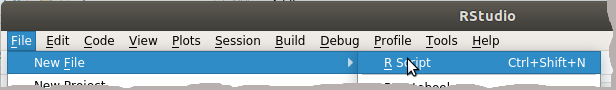

Uma nova aba, chamada *Untitled1* deve abrir-se:

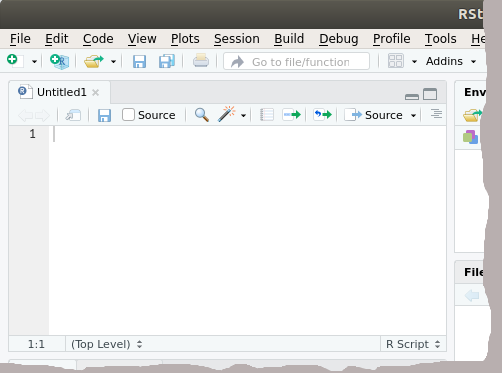

Coloque, dentro desta nova área, a tabuada do 3 que ensaiamos acima, digitando:

```r
# Este é meu primeiro RScript
cat("Apresentando a tabuada do 3\n")
for (n in 0:10)
{
  cat(n,"x",3,"=",n*3,"\n")
}
```

Entenda a sintaxe do R:

- O símbolo de *hashtag* indica uma linha de comentário (algo para você lembrar o que faz determinado trecho de um *RScript*, que não será executada).
- *cat()* é uma função R que ecoa na Console o texto que for passado como parâmetro; neste exemplo, o primeiro *cat()* apenas escreve “Apresentando a tabuada do 3” e avança uma linha (por causa do caracter especial **\n**).
- o *for()* já foi apresentado, e faz a variável **n** assumir os valores 0, 1, 2, …, 10.
- tudo que está entre as chaves, {…}, é executado repetidamente a cada ciclo do *for()*.
- este segundo *cat* tem parte do texto fixo com parte variável, ecoando o resultado de cada multiplicação, uma em cada linha.

Salve seu *RScript* na mesma pasta em que está o projeto, usando

*File -> Save*

com o nome **tabuada3.R**. Agora a aba tem o nome do arquivo que acabou de ser criado.

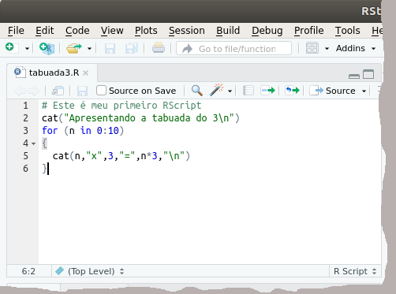

Execute seu *RScript* clicando o botão [Source] e observe o resultado na *Console*

```
Apresentando a tabuada do 3
```

```
0 x 3 = 0
1 x 3 = 3
2 x 3 = 6
3 x 3 = 9
4 x 3 = 12
5 x 3 = 15
6 x 3 = 18
7 x 3 = 21
8 x 3 = 24
9 x 3 = 27
10 x 3 = 30
```

## Lendo arquivo de dados

Existem formas de ler vários tipos de arquivo com R. As duas formas mais comuns são um arquivo texto que utilize algum tipo de delimitador (vírgula, ponto e vírgula ou caracteres de tabulação são os mais comuns), ou planilhas (o formato Excel, “xls” ou “xlsx” são os mais difundidos).

Arquivos no formato texto são simples e completamente portáveis entre diferentes sistemas operacionais. Há problemas, porém, com a comunicação com pesquisadores menos habituados a eles: atrapalham-se com os delimitadores, criam arquivos usando vírgulas como separador decimal (misturando-os com vírgulas usadas como delimitadores e, assim, bagunçando os dados de colunas diferentes), digitam números ora com pontos decimais, ora com vírgulas (bagunçando os dados numéricos ao transformar 1300 em 1.3 ou levar o sistema operacional a interpretar 1,3 como se fosse um texto) ou esquecem de especificar os delimitadores.

### Arquivos em formato texto

Para este exemplo lidaremos com um arquivo *MetodoAnticoncepcional.txt*, que deve ser baixado e colocado na pasta do projeto. Ele aparecerá na lista de arquivos, junto aos arquivos Anticoncepcional.Rproj e tabuada3.R mencionados acima. Este é um exemplo hipotético, usando o seguinte enredo:

> Um agente comunitário do programa de saúde da família deseja escrever um pequeno texto alertando os jovens de sua comunidade sobre o problema da gravidez indesejada. Com este propósito, ele decide investigar quais os métodos que os jovens estão usando.

> Após pesquisa realizada com 60 jovens (14 – 19 anos), escolhidos aleatoriamente, obteve as respostas contidas em um arquivo texto.

Este é um arquivo texto tem 61 linhas. A primeira linha tem os nomes das colunas (que se tornarão os nomes das variáveis) e, em seguida, os dados de cada indivíduo (um indivíduo em cada linha).

Você pode ter uma ideia do arquivo com a ajuda do RStudio: basta clicar sobre ele na área de *Files*, e o arquivo se abrirá em uma nova janela à esquerda. Agora o RStudio mostra quatro áreas:

[figure not shown]

A *Console* foi deslocada para baixo e o arquivo *MetodoAnticoncepcional.txt* está aberto em uma nova aba.

Este arquivo ainda não foi convertido a um formato com o qual R possa lidar, tanto que as colunas parecem desalinhadas por causa dos conteúdos com diferentes larguras. As colunas estão separadas por caracteres de tabulação (*tabs*, que normalmente têm a mesma aparência de um espaço em branco, dando a impressão de que as colunas estão desalinhadas, um dos motivos para a confusão que estes arquivos causam para usuários “*não iniciados*”).

Repare, também, que não foram utilizada letras acentuadas nos nomes das variáveis (Metodo em vez de Método); caso o faça, poderá ter que lidar com alguns problemas adicionais, especialmente quando seu sistema operacional (a.k.a. **Ru**indows) não resolva sozinho (com o passar dos anos os problemas diminuiram, mas é melhor não arriscar: sugere-se evitar acentos em nomes de variáveis e em nomes de arquivos).

Variáveis, em R, podem ter estruturas mais elaboradas do que as que contém apenas um valor ou um vetor com valores de mesma natureza. Criaremos uma, chamada **df_metodos**, que conterá toda a informação que está neste arquivo *.txt* com o seguinte comando no console (janela à esquerda):

```r
df_metodos <- read.table("MetodoAnticoncepcional.txt", header=TRUE,  dec=".", sep="\t")
```

Repare as especificações sobre o arquivo que foram passadas para a função *read.table()*:

- `header=TRUE` informa que a primeira linha deve ser usada como nome das variáveis;
- `dec=“.”` informa que ponto, se existir, é o separador decimal usado;
- `sep=“”` informa o uso do tab como delimitador.

Na janela *Environment* (superior-direita) aparece a variável **df_metodos**, mostrando que a importação aconteceu. Clique no nome da variável e na seta que aparece ao lado esquerdo do nome da variável para ver algumas informações sobre seus detalhes, e sobre o nome da variável para que o RStudio mostre-lhe seu conteúdo:

[figure not shown]

Como pode observar, o RStudio lhe informa que **df_metodos** contém três variáveis:

- ID, do tipo int (número inteiro, quantitativa)
- Idade, do tipo int (número inteiro, quantitativa)
- Metodo, fator com 4 níveis

A identificação do tipo de variável é automática, de acordo com o conteúdo encontrado. Não havia números fracionários, então `dec=“.”` não era necessário (o símbolo usado como separador decimal - quem importa arquivo texto precisa saber se os números foram escritos com a notação inglesa, usando pontos, ou portuguesa, usando vírgulas). **ID**, identificação do indivíduo, foi identificada como numérica, embora não o seja, mas não atrapalha muito deixar assim por enquanto. **Idade**, ao contrário, interessa como variável quantitativa, foi identificada como tal, e podemos fazer cálculos com ela. A coluna **Metodo** foi reconhecida, corretamente, como fator, i.e., pode ser usada para separar grupos. Como é variável categórica (veremos, adiante, que são 4 categorias), podemos fazer contagens.

Além de conhecer os tipos de variável de cada coluna, precisamos saber qual é o tipo de **df_metodos**. Use (na *Console*) o comando:

```r
is.table(df_metodos)
```

```
[1] FALSE
```

O que é uma surpresa! Apesar do nome e do comando de importação, **df_metodos** **NÃO É** do tipo *table*. Experimente:

```r
is.data.frame(df_metodos)
```

```
[1] TRUE
```

**df_metodos** é um *data frame*. Confuso, mas muito conveniente. A função *read.table()*, lê um arquivo que encaramos como uma “tabela”, mas cria (retorna) um *data frame*, o qual guardamos em **df_metodos**; é um formato muito flexível, como veremos adiante. Adicionalmente, note o motivo para termos escolhido o prefixo **df_** para o nome da variável, neste exemplo, ajudando-nos a lembrar do tipo da variável.

| Uma das coisas confusas em R, especialmente para quem conhece outras linguagens de programação, é a quantidade de tipos diferentes de variáveis. Há uma série de comandos em R para que se verifique qua… |
| --- |

### Arquivos em formato Excel

Os arquivos em formato texto, para quem não sabe lidar com eles, podem trazer dificuldades. Sendo o formato do Excel muito comum, muitas vezes (mesmo para quem sabe lidar com arquivos texto) é mais conveniente receber e enviar dados neste formato, para comunicar-se com as outras pessoas, que usam computadores mas nunca ouviram falar, nem estão interessadas em ouvir, sobre sistemas operacionais, linguagens de programação, separadores ou delimitadores.

Basta que a planilha, neste caso, esteja estruturada com a mesma regra que usamos para o arquivo-texto: a primeira linha pode conter os nomes das variáveis (se houver acentos, sugere-se que os remova) e cada linha abaixo desta deve conter os dados de um indivíduo ou uma unidade experimental.

O RStudio tem um mecanismo de importação em um quadrinho do *Environment*, “*Import Dataset*”. Pode experimentar com ele mas, como em tudo no RStudio, é uma operação que o R faz sozinho, e é bom saber como seria em uma *Console* “pura” (e que, depois, você pode colocar em um *RScript*).

| O ambiente do RStudio é um facilitador. Os puristas do R podem preferir um terminal, que funciona como a *Console* sem a ajuda do ambiente do RStudio. Assim, tudo que aparece nas janelas do RStudio é,… |
| --- |

Baixe o arquivo *MetodoAnticoncepcional.xlsx* para a pasta do projeto (este é um arquivo Excel com os mesmos dados do arquivo texto que utilizamos acima). Clique sobre o nome do arquivo (na aba *Files*) e escolha *Import Dataset*: obterá um *data frame*.

Repare na *Console*: o RStudio automatiza mas mostra a operação que fez através do RStudio:

```r
library(readxl)
MetodoAnticoncepcional <- read_excel("MetodoAnticoncepcional.xlsx")
View(MetodoAnticoncepcional)
```

A função *library()* aparece pela primeira vez neste texto. A segunda função, *read_excel()* lê a planilha e o operador de atribuição, **<-**, coloca seu conteúdo em uma variável que tem o nome da planilha (o que pode não ser conveniente). A terceira linha invoca a função *View*, que exibe a variável da mesma forma que obtivemos acima, quando clicamos sobre o nome da variável na aba *Environment*. Os dois primeiros comandos podem ser executados na *Console* com resultados idênticos.

A vantagem de usar os comandos na *Console* ou dentro de um *RScript* é que você poderá escolher um nome de variável que lhe convenha:

```r
library(readxl)
deste.nome.eu.gosto.mais <- read_excel("MetodoAnticoncepcional.xlsx")
```

O que fazem?

- *library()* ativa um *package* (pacote). As funções do R fazem parte de pacotes. Na primeira instalação do R é comum termos apenas o **r-base**, já mencionado, e todas as funções vistas até aqui estão definidas nele.
- A função *read_excel()*, é uma das funções de *readxl*, portanto só funciona depois que *library(readxl)* for executada uma vez.

Antes de executar a função *read_excel()*, a library (que vem no pacote) *readxl* tem que ser ativada.

O pacote precisa ter sido instalado previamente ou você receberá mensagens de erro. No caso do RStudio, *readxl* vem instalada. Em outros ambientes pode estar faltando.

Caso *readxl* nunca tenha sido instalada, a mensagem de erro será algo como:

Error in library(readxl) : there is no package called ‘readxl’

Neste caso, precisará instalar com:

```r
install.packages("readxl")
```

e seguir as instruções na tela.

Ainda há um detalhe: fazer isto dentro do RStudio funciona bem no Windows, mas não deve ser feito no Linux ou Macintosh. Isto porque o Windows é desprotegido, e o usuário é administrador da máquina o tempo todo. Nos outros sistemas operacionais mencionados, abra um terminal e inicie o R *Console* como root. Em meu Ubuntu, por exemplo, o comportamento do terminal é assim:

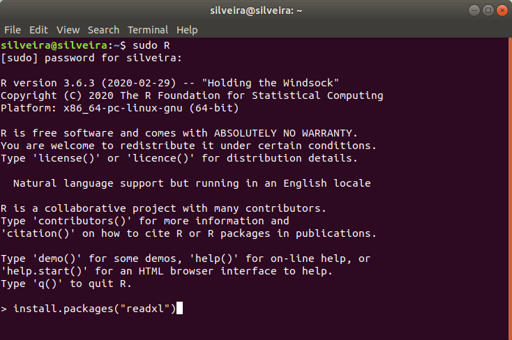

Um instalação, geralmente, escreve várias coisas no terminal, que o instalador precisará ler **apenas no caso de algo dar errado**. Observe, principalmente, as últimas linhas. Caso termine com

* DONE (readxl)

sua instalação foi bem sucedida.

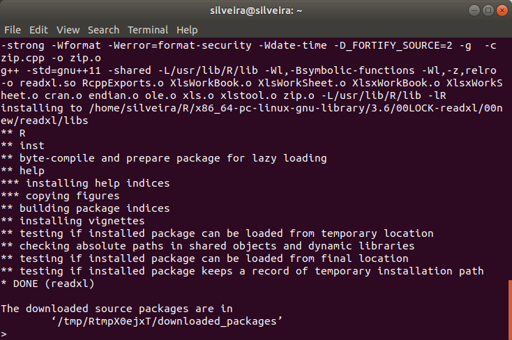

### Arquivos em outros formatos

Há alguns outros formatos pré-instalados no RStudio. Funcionará como no caso do Excel. Por exemplo, para SPSS:

```r
library(haven)
dt_anxproc1 <- read_sav("AnxietyProcrastination.sav")
```

Para o formato do LibreOffice (*.ods*) não há nada pronto no RStudio. Não é problema: existe *package* para isto, como:

```r
install.packages("readODS", dep = TRUE)
library(readODS)
dt_anxproc2 <- read_ods("AnxietyProcrastination.ods")
```

Caso os execute serão criados *data frames*, respectivamente chamados **dt_anxproc1** e **dt_anxproc2**, ambos com o mesmo conteúdo (claramente, é preciso antes baixar os arquivos *AnxietyProcrastination.sav* e *AnxietyProcrastination.ods* para a pasta do projeto).

## Manipulando um data frame

### retomando o *data frame*

Vamos retormar o *data frame* **df_metodos** com os seguintes comandos, já executados:

```r
library(readxl)
df_metodos <- read.table("MetodoAnticoncepcional.txt", header=TRUE,  dec=".", sep="\t")
is.data.frame(df_metodos)
```

```
[1] TRUE
```

### acessando elementos individuais de um *data frame*

Podemos verificar tanto o conteúdo das colunas de um *data frame* quanto os tipos de variável nele contidos.

O conteúdo das colunas podem ser acessados, fornecendo simplesmente o nome da variável:

```r
df_metodos$Idade
```

```
 [1] 15 15 16 17 16 15 17 16 17 16 16 17 15 15 14 16 16 18 14 16 17 16 15
[24] 16 17 18 18 15 16 16 16 14 15 15 16 17 14 16 15 16 16 15 16 18 19 18
[47] 18 16 17 18 15 17 16 16 18 15 17 15 16 15
```

Note o símbolo **$**, significando que queremos a coluna **Idade** que está dentro do *data frame* **df_metodos**.

Os números entre colchetes à esquerda representam a posição do primeiro elemento exibido em cada linha. Por exemplo, o primeiro elemento contém o valor 15

```r
df_metodos$Idade[1]
```

```
[1] 15
```

o vigésimo primeiro elemento contém o valor 17:

```r
df_metodos$Idade[21]
```

```
[1] 17
```

o quadragésimo quinto contém o valor 19:

```r
df_metodos$Idade[45]
```

```
[1] 19
```

e o último elemento contém o valor 15:

```r
df_metodos$Idade[60]
```

```
[1] 15
```

Em situações em que o número de linhas (*rows*, em inglês) não é conhecido, o último elemento pode ser acessado com:

```r
df_metodos$Idade[nrow(df_metodos)]
```

```
[1] 15
```

A função *nrow()*, aninhada dentros dos colchetes, devolve o número de linhas que **df_metodos** tem; neste caso:

```r
nrow(df_metodos)
```

```
[1] 60
```

devolve o valor 60.

Os elementos da coluna **df_metodos$Idade** são todos números inteiros:

```r
is.numeric(df_metodos$Idade)
```

```
[1] TRUE
```

```r
is.integer(df_metodos$Idade)
```

```
[1] TRUE
```

E podemos perguntar se são, por exemplo, finitos (e, neste caso, cada valor é verificado):

```r
is.finite(df_metodos$Idade)
```

```
 [1] TRUE TRUE TRUE TRUE TRUE TRUE TRUE TRUE TRUE TRUE TRUE TRUE TRUE TRUE
[15] TRUE TRUE TRUE TRUE TRUE TRUE TRUE TRUE TRUE TRUE TRUE TRUE TRUE TRUE
[29] TRUE TRUE TRUE TRUE TRUE TRUE TRUE TRUE TRUE TRUE TRUE TRUE TRUE TRUE
[43] TRUE TRUE TRUE TRUE TRUE TRUE TRUE TRUE TRUE TRUE TRUE TRUE TRUE TRUE
[57] TRUE TRUE TRUE TRUE
```

Em conexão com o comentário, acima, de que em R há muitos tipos de variáveis que não têm correspondência em outras linguagens de programação, note também que uma variável pode ser vista como se tivesse vários “tipos” e ou “subtipos” simultaneamente. Por exemplo, a coluna **Idade**, além de numérica, inteira, contendo números finitos, também pode ser tratada como um vetor.

```r
is.vector(df_metodos$Idade)
```

```
[1] TRUE
```

A coluna **Metodo**, obviamente, não é numérica:

```r
is.numeric(df_metodos$Metodo)
```

```
[1] FALSE
```

mas é um fator, como já foi mencionado:

```r
is.factor(df_metodos$Metodo)
```

```
[1] TRUE
```

(voltaremos a lidar com fatores adiante)

*Data frames* são organizados em `[linha,coluna]`. É possível acessar uma linha específica de um *data frame* pelo seu número. A segunda linha contém:

```r
df_metodos[2,]
```

```
# A tibble: 1 x 3
     ID Idade Metodo
  <int> <int> <fct>
1     2    15 Tabelinha
```

Podemos também acessar uma coluna, como alternativa a usar o nome da coluna com o símbolo **$**, por seu número. A terceira coluna contém:

```r
df_metodos[,3]
```

```
 [1] Tabelinha    Tabelinha    Preservativo Pílula       Pílula
 [6] Tabelinha    Tabelinha    Preservativo Pílula       Preservativo
[11] Preservativo Preservativo Outro        Pílula       Preservativo
[16] Tabelinha    Tabelinha    Outro        Pílula       Outro
[21] Preservativo Pílula       Tabelinha    Tabelinha    Tabelinha
[26] Pílula       Tabelinha    Preservativo Preservativo Tabelinha
[31] Outro        Tabelinha    Tabelinha    Preservativo Pílula
[36] Pílula       Preservativo Preservativo Preservativo Outro
[41] Tabelinha    Tabelinha    Pílula       Tabelinha    Pílula
[46] Preservativo Preservativo Tabelinha    Preservativo Pílula
[51] Tabelinha    Tabelinha    Preservativo Preservativo Pílula
[56] Tabelinha    Tabelinha    Pílula       Preservativo Tabelinha
Levels: Outro Pílula Preservativo Tabelinha
```

(note, na última linha, que R já informa as quatro categorias que encontrou com `Levels: Outro Pílula Preservativo Tabelinha`).

Podemos combinar linha e coluna. O conteúdo da segunda linha, terceira coluna contém:

```r
df_metodos[2,3]
```

```
[1] Tabelinha
Levels: Outro Pílula Preservativo Tabelinha
```

Também é possível filtrar por determinadas condições. As linhas dos indivíduos com idade menor ou igual a 15 anos são:

```r
df_metodos[df_metodos$Idade<=15,]
```

```
# A tibble: 19 x 3
      ID Idade Metodo
   <int> <int> <fct>
 1     1    15 Tabelinha
 2     2    15 Tabelinha
 3     6    15 Tabelinha
 4    13    15 Outro
 5    14    15 Pílula
 6    15    14 Preservativo
 7    19    14 Pílula
 8    23    15 Tabelinha
 9    28    15 Preservativo
10    32    14 Tabelinha
11    33    15 Tabelinha
12    34    15 Preservativo
13    37    14 Preservativo
14    39    15 Preservativo
15    42    15 Tabelinha
16    51    15 Tabelinha
17    56    15 Tabelinha
18    58    15 Pílula
19    60    15 Tabelinha
```

### alterando o conteúdo do data frame

Como podemos acessar os elementos de um *data frame*, podemos também alterar seus valores usando o operador de atribuição, **<-**. Por exemplo:

```r
df_metodos$Idade[45] <- 19.5
```

e confira com

```r
df_metodos$Idade
```

```
 [1] 15.0 15.0 16.0 17.0 16.0 15.0 17.0 16.0 17.0 16.0 16.0 17.0 15.0 15.0
[15] 14.0 16.0 16.0 18.0 14.0 16.0 17.0 16.0 15.0 16.0 17.0 18.0 18.0 15.0
[29] 16.0 16.0 16.0 14.0 15.0 15.0 16.0 17.0 14.0 16.0 15.0 16.0 16.0 15.0
[43] 16.0 18.0 19.5 18.0 18.0 16.0 17.0 18.0 15.0 17.0 16.0 16.0 18.0 15.0
[57] 17.0 15.0 16.0 15.0
```

(localize o 45<sup>0</sup> elemento e veja que seu valor é, agora, 19.5).

Mais uma coisa aconteceu. Notou que todos os valores apareceram com uma casa decimal? Repare na janela *Environment*: **df_metodos$Idade**, que era **int**, agora é **num**. Ao colocar um único valor com casa decimal, todo o vetor foi alterado para acomodá-lo. Verifique:

```r
is.integer(df_metodos$Idade)
```

```
[1] FALSE
```

```r
is.numeric(df_metodos$Idade)
```

```
[1] TRUE
```

```r
is.double(df_metodos$Idade)
```

```
[1] TRUE
```

A coluna não é mais feita com valores inteiros, mas ainda é numérica, do tipo **double** (a forma do R dizer que é número fracionário).

A esta altura você pode imaginar que devem existir muitas funções R iniciadas com *is…()* e que pode ser um jogo insano ficar tentando várias até adivinhar com qual tipo estamos lidando. Podemos reproduzir na *Console* as informações de uma variável que aparecem na aba *Environment* com a função *str()* (de *structure*, estrutura):

```r
str(df_metodos)
```

```
'data.frame':   60 obs. of  3 variables:
 $ ID    : int  1 2 3 4 5 6 7 8 9 10 ...
 $ Idade : num  15 15 16 17 16 15 17 16 17 16 ...
 $ Metodo: Factor w/ 4 levels "Outro","Pílula",..: 4 4 3 2 2 4 4 3 2 3 ...
```

Ajuda, ainda, conhecer a função *sapply()*:

```r
sapply(df_metodos, typeof)
```

```
       ID     Idade    Metodo
"integer"  "double" "integer"
```

que informa o tipo *double* para **df_metodos$Idade** (e mostra, esquisitamente, que **df_metodos$Metodo**, sendo um fator, tem números inteiros associados com cada categoria).

Como sempre, se usamos apenas o nome da variável **df_metodos** na *Console*, R tenta exibir todo seu conteúdo:

```r
df_metodos
```

```
# A tibble: 60 x 3
      ID Idade Metodo
   <int> <dbl> <fct>
 1     1    15 Tabelinha
 2     2    15 Tabelinha
 3     3    16 Preservativo
 4     4    17 Pílula
 5     5    16 Pílula
 6     6    15 Tabelinha
 7     7    17 Tabelinha
 8     8    16 Preservativo
 9     9    17 Pílula
10    10    16 Preservativo
# … with 50 more rows
```

Como são muitas linhas, R trunca e informa quantas não exibiu. Tentar mostrar um *data frame* desta forma, portanto, não é muito prático; usar o ambiente do RStudio através da aba *Environment* é muito mais fácil.

Note, ainda, os números das linhas à esquerda. Estes são os números de linha de **df_metodos**. Neste caso é apenas uma coincidência, pois os pacientes foram numerados sequencialmente no arquivo original, que sejam iguais a **df_metodos$ID**.

### alterando o tipo de variável

Caso lhe incomode que **df_metodos$ID** seja um número, um tipo pode ser convertido em outro:

```r
df_metodos$ID <- as.character(df_metodos$ID)
```

Repare que a função é *as.character*, significando **como letra** (e não *is.character()*, que pergunta se **é letra?**).

Também pode ser estranho atribuir a **df_metodos$ID** uma operação feita com a própria variável. O que acontece aqui é pegar **df_metodos$ID**, converter em caracteres, e atribuir (sobrepor) o que aconteceu à própria **df_metodos$ID**. Confira:

```r
str(df_metodos)
```

```
'data.frame':   60 obs. of  3 variables:
 $ ID    : chr  "1" "2" "3" "4" ...
 $ Idade : num  15 15 16 17 16 15 17 16 17 16 ...
 $ Metodo: Factor w/ 4 levels "Outro","Pílula",..: 4 4 3 2 2 4 4 3 2 3 ...
```

## Gravando um data frame

Depois de alterar como precisa um *data frame*, você pode querer armazená-lo, para uso futuro, em um arquivo em formato proprietário do R, use:

```r
save(df_metodos, file="metodos.Rdata")
```

e veja que aparece um arquivo chamado **metodos.Rdata** na aba _Files. Seu conteúdo é o estado atual de **df_metodos**.

Vamos destruir a variável **df_metodos** com

```r
df_metodos <- NULL
```

(observe a aba *Environment*).

Para recuperar **df_metodos** use:

```r
load("metodos.Rdata")
```

O arquivo *.Rdata*, além dos dados, preserva o nome que da variável nele salva.

## Lendo outro arquivo de dados

Seguindo a máxima de que *There ain’t no such thing as a free lunch* (não existe almoço de graça), o que acontece se, para facilitar a vida, evitássemos os arquivos em formato texto e optássemos pelo consagrado formato do Excel. Já comentados que complicações com pontos ou vírgulas decimais ou separação entre as colunas por tabs ou outros caracteres são evitadas. Qual é o preço?

Vamos sobrepor **df_metodos** com o que parece ser conteúdo idêntico, porém guardado no arquivo *MetodoAnticoncepcional.xlsx*. O comando R, já visto, é:

```r
library(readxl)
df_metodos <- read_excel("MetodoAnticoncepcional.xlsx")
```

A estrutura do *data frame*, agora, é:

```r
str(df_metodos)
```

```
Classes 'tbl_df', 'tbl' and 'data.frame':   60 obs. of  3 variables:
 $ ID    : num  1 2 3 4 5 6 7 8 9 10 ...
 $ Idade : num  15 15 16 17 16 15 17 16 17 16 ...
 $ Metodo: chr  "Tabelinha" "Tabelinha" "Preservativo" "Pílula" ...
```

```r
sapply(df_metodos, typeof)
```

```
         ID       Idade      Metodo
   "double"    "double" "character"
```

Portanto, **df_metodos** que antes continha três colunas

- ID : chr “1” “2” “3” “4” …
- Idade : num 15 15 16 17 16 15 17 16 17 16 …
- Metodo: Factor w/ 4 levels

agora tem, *num*, *num* e *chr*). Vieram assim, possivelmente, por causa de como os dados foram formatados pelo Excel quando os digitamos.

Então, sugerimos que sempre confira o que foi lido e coloque no jeito adequado, antes de começar a manipular os dados. Neste exemplo:

```r
df_metodos$ID <- as.character(df_metodos$ID)
df_metodos$Metodo <- as.factor(df_metodos$Metodo)
str(df_metodos)
```

```
Classes 'tbl_df', 'tbl' and 'data.frame':   60 obs. of  3 variables:
 $ ID    : chr  "1" "2" "3" "4" ...
 $ Idade : num  15 15 16 17 16 15 17 16 17 16 ...
 $ Metodo: Factor w/ 4 levels "Outro","Pílula",..: 4 4 3 2 2 4 4 3 2 3 ...
```

```r
sapply(df_metodos, typeof)
```

```
         ID       Idade      Metodo
"character"    "double"   "integer"
```

Nada fizemos com **df_metodos$Idade** porque, aqui, é irrelevante se são números inteiros ou reais (_double). Caso fosse necessário (por exemplo, se fosse uma variável quantitativa discreta como o número de filhos e fizéssemos questão de tratar tudo como números inteiros), bastaria adicionar:

```r
df_metodos$Idade <- as.integer(df_metodos$Idade)
```

e conferir:

```r
str(df_metodos)
```

```
Classes 'tbl_df', 'tbl' and 'data.frame':   60 obs. of  3 variables:
 $ ID    : chr  "1" "2" "3" "4" ...
 $ Idade : int  15 15 16 17 16 15 17 16 17 16 ...
 $ Metodo: Factor w/ 4 levels "Outro","Pílula",..: 4 4 3 2 2 4 4 3 2 3 ...
```

```r
sapply(df_metodos, typeof)
```

```
         ID       Idade      Metodo
"character"   "integer"   "integer"
```

## Lidando com variável qualitativa

Este arquivo é pequeno e podemos ler todas as linhas da variável *Metodo*. Mas e se o arquivo fosse maior? Quantos métodos diferentes foram citados? Um comando útil (sempre na *Console*) é

```r
unique(df_metodos$Metodo)
```

```
[1] Tabelinha    Preservativo Pílula       Outro
Levels: Outro Pílula Preservativo Tabelinha
```

Usuários Windows podem ter problemas com a acentuação (Pílula, com acento agudo neste caso). Desde 1993 foi lançado o https://en.wikipedia.org/wiki/UTF-8 UTF-8, um padrão adotado para representar caracteres de diferentes países. Segundo a Wikipedia, é o padrão adotado por 93.7% de todas as páginas da Web. É o padrãp normal para Linux (no qual gerei o arquivo) e para Macintosh, mas ainda não deu tempo para a Microsoft implementá-lo.

Se é seu caso, há uma possível solução. O comando:

```r
df_metodos$Metodo[substr(df_metodos$Metodo,3,6)=="lula"] <- "Pilula"
```

e confira com

```r
unique(df_metodos$Metodo)
```

Este comando deve ter substituído por Pilula (sem acento) todas as ocorrências de Pílula (com acento agudo na letra i), seja qual for o caracter pelo qual o Windows tenha substituído o i acentuado.

**Como não tenho este problema no Linux Ubuntu, os exemplos abaixo continuam com Pílula (acentuada).**

Temos, portanto, 4 métodos na coluna **df_metodos$Metodo**. É bom verificar com a função *unique()* porque, em variáveis contendo textos, é comum haver erro na digitação dos dados. Podemos verificar quantas ocorências de cada:

```r
table(df_metodos$Metodo)
```

[output not shown]

Existe uma outra função, *summary()*, em determinadas situações equivalente, mas pode ser que responda assim:

```r
summary(df_metodos$Metodo)
```

```
   Length     Class      Mode
       60 character character
```

Caso isto aconteça, é porque **df_metodos$Metodo** está com o tipo errado (caracteres, no caso). É só arrumar:

```r
is.character(df_metodos$Metodo)
```

```
[1] TRUE
```

```r
is.factor(df_metodos$Metodo)
```

```
[1] FALSE
```

```r
df_metodos$Metodo <- as.factor(df_metodos$Metodo)
is.character(df_metodos$Metodo)
```

```
[1] FALSE
```

```r
is.factor(df_metodos$Metodo)
```

```
[1] TRUE
```

```r
summary(df_metodos$Metodo)
```

```
       Outro       Pílula Preservativo    Tabelinha
           5           14           19           22
```

Caso eu prefira ver as contagens em porcentagem, em vez de números absolutos, posso usar assim:

```r
contagem <- table(df_metodos$Metodo)
contagem/sum(contagem)*100
```

```
       Outro       Pílula Preservativo    Tabelinha
    8.333333    23.333333    31.666667    36.666667
```

**Entenda o código**:

Note que a variável **contagem**, criada com a função *table()* é uma tabela:

```r
is.table(contagem)
```

```
[1] TRUE
```

Já tínhamos visto o comando `summary(df_metodos$Metodo)` que devolvia as contagens do número de ocorrências de cada categoria da coluna **Metodo** dentro da **df_metodos**. O operador ‘<-’ é o operador de atribuição e, então,

`contagem <- summary(df_metodos$Metodo)`

em vez de ecoar na tela, cria uma variável chamada **contagem** para armazenar o resultado de *summary()*. Esta **contagem** tem os 4 valores, correspondendo às ocorrências de Tabelinha, Preservativo, Pílula e Outro

Com a função *sum()* (soma), que totaliza os valores da variável **contagem**. O comando `contagem/sum(contagem)*100` pega cada valor de **contagem**, divide por **`sum(contagem)`** e multiplica por **100** para transformar em porcentagem. Como existem 4 valores, a saída traz 4 resultados.

Um gráfico do tipo *pie* (torta) ou, como gostamos mais, pizza:

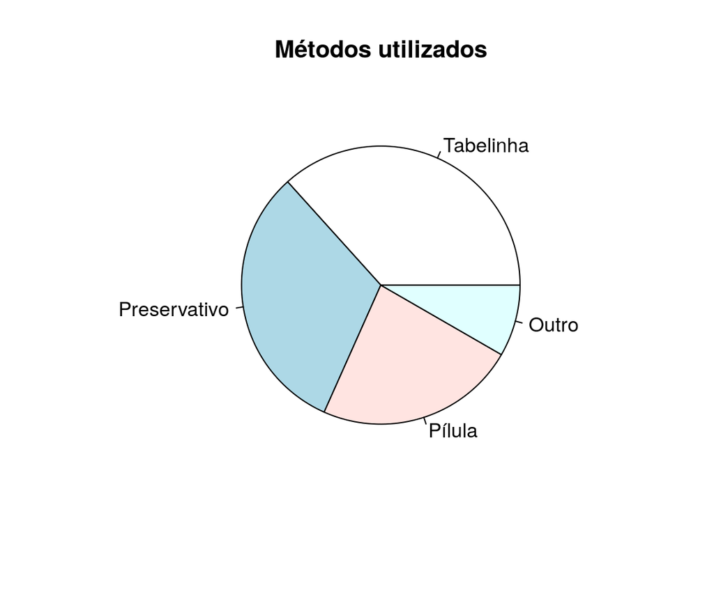

```r
fatias <- c(22,19,14,5)
nomes <- c("Tabelinha","Preservativo","Pílula","Outro")
pie(fatias, labels=nomes, main="Métodos utilizados")
```

***

A função *pie()* pode receber outros valores além dos números, nomes das fatias e título para o gráfico.

Para acessar a documentação desta ou de qualquer outra função R, use o operador ‘?’. Por exemplo, experimente na *Console* do RStudio:

```r
?pie
```

e observe a aba *Help* com sua documentação.

Quer ver uma gracinha?

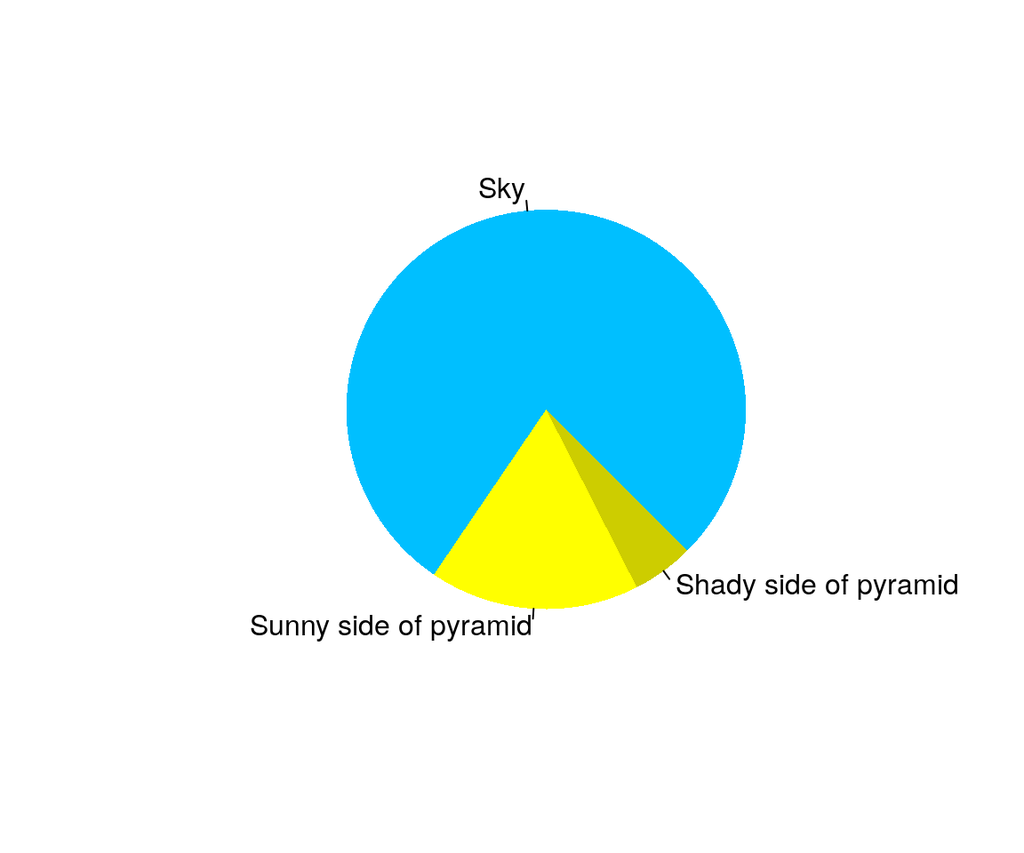

```r
pie(c(Sky = 78, "Sunny side of pyramid" = 17, "Shady side of pyramid" = 5), init.angle = 315, col = c("deepskyblue", "yellow", "yellow3"), border = FALSE)
```

(quem me chamou a atenção sobre este gráfico foi Fernando Sacramento; é um dos exemplos da documentação da função no R).

O gráfico dos métodos anticoncepcionais terá exatamente a mesma aparência se o apresentarmos em porcentagens. Aqui são apenas 4 fatias, e eu poderia trocar os valores de fatias por suas respectivas porcentagens. No entanto, não é necessário todo o trabalho; podemos criar os vetores **fatias** e **nomes** com comandos do R e tornar esta sequência de comandos mais fácil de ajustar para outras tabelas. Experimente:

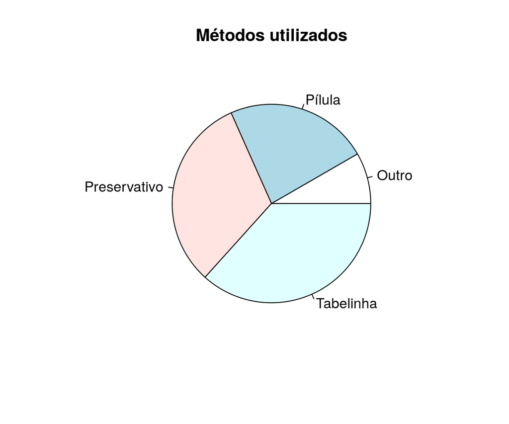

| Repare o uso de um comentário: tudo que escrever após # não é executado A variável *fatias* recebe os números 5, 14, 19 e 22. Então *fatias* é sobrescrita com as próprias porcentagens (frequências rel… |
| --- |

```r
# fatias recebem os números da tabela
fatias <- as.vector(contagem)
# transforma em porcentagem
fatias <- fatias/sum(fatias)*100
# nomes recebem os nomes das colunas da tabela
nomes <- names(contagem)
pie(fatias, labels=nomes, main="Métodos utilizados")
```

## Lidando com variável quantitativa

Neste exemplo podemos explorar a idade dos indivíduos. Sendo variável numérica, podemos usar funções que envolvem cálculos e, assim, ter medidas de localização e de dispersão.

Para começar, descrever a variável. Para variáveis numéricas, *table()* e *summary()* têm comportamentos diferentes:

```r
table(df_metodos$Idade)
```

```
14 15 16 17 18 19
 4 15 22 10  8  1
```

```r
summary(df_metodos$Idade)
```

```
   Min. 1st Qu.  Median    Mean 3rd Qu.    Max.
   14.0    15.0    16.0    16.1    17.0    19.0
```

Podemos computar:

- Média aritmética:

```r
mean(df_metodos$Idade)
```

```
[1] 16.1
```

- Variância:

```r
var(df_metodos$Idade)
```

```
[1] 1.379661
```

- Desvio-padrão assim:

```r
sd(df_metodos$Idade)
```

```
[1] 1.17459
```

ou assim:

```r
var(df_metodos$Idade)**0.5
```

```
[1] 1.17459
```

O operador ** é potência (elevar a 0.5 equivale à raiz quadrada) Também pode ser usado como ^ com resultado idêntico:

```r
var(df_metodos$Idade)^0.5
```

```
[1] 1.17459
```

- Mediana:

```r
median(df_metodos$Idade)
```

```
[1] 16
```

- Quartis:

```r
quantile(df_metodos$Idade, probs=seq(0,1,0.25))
```

```
  0%  25%  50%  75% 100%
  14   15   16   17   19
```

- Intervalo interquartílico e amplitude:

```r
quartil <- quantile(df_metodos$Idade, probs=seq(0,1,0.25))
cat("IQ: ",quartil[4]-quartil[2])
```

```
IQ:  2
```

```r
cat("A: ",quartil[5]-quartil[1])
```

```
A:  5
```

Duas observações:

- A função *seq()* cria uma sequência para as probabilidades, neste caso `seq(0,1,0.25)` iniciando com o valor 0, terminando em 1, com passo de 0.25: cria, portanto, os valores 0, 0.25, 0.5, 0.75 e 1.0 que correspondem aos quartis desejados.
- A função que computa os quartis é *quantile()*, não é *qua**r**tile()*. Esta função não é para computar apenas quartis, mas qualquer qua**n**til; é só alterar a função *seq()* de forma adequada. Por exemplo:

```r
quantile(df_metodos$Idade, probs=seq(0,1,0.1))
```

```
  0%  10%  20%  30%  40%  50%  60%  70%  80%  90% 100%
  14   15   15   15   16   16   16   17   17   18   19
```

fornece as divisões de 10% em 10%.

Podemos, ainda, produzir gráficos. Dois dos mais conhecidos são o histograma:

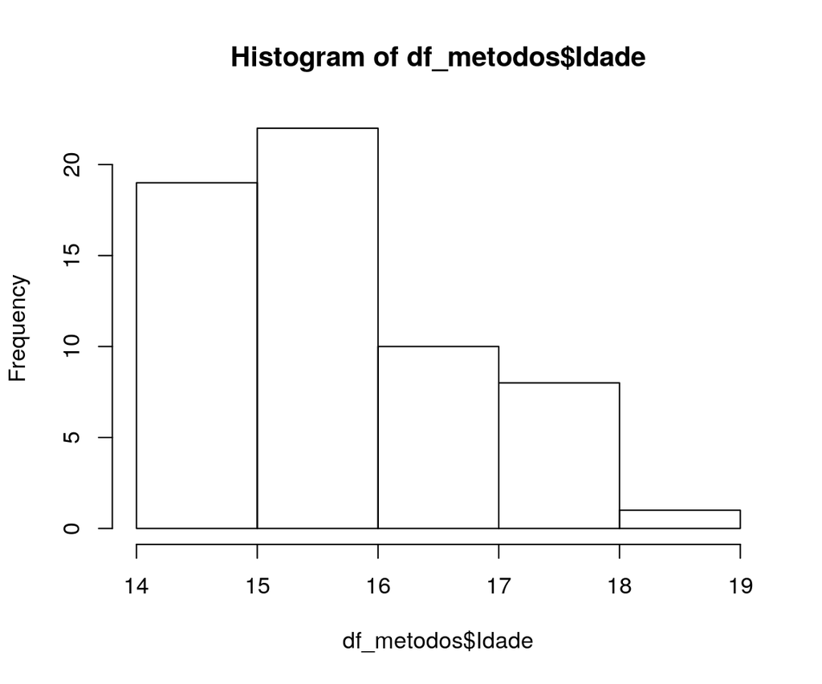

```r
hist(df_metodos$Idade)
```

e o boxplot:

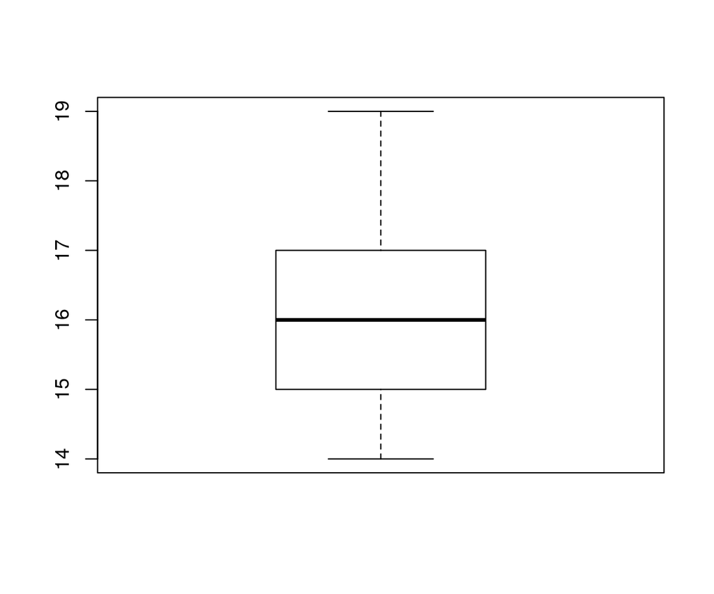

```r
boxplot(df_metodos$Idade)
```

Uma forma melhor e mais sofisticada é converter as idades em densidade de probabilidade e usar um *density plot*:

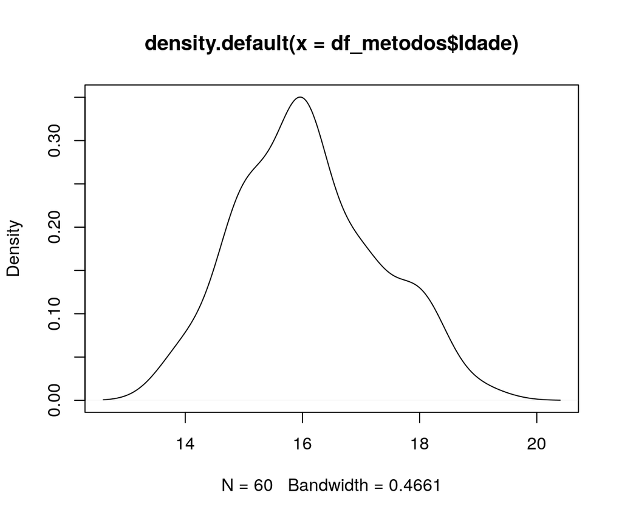

```r
densidade <- density(df_metodos$Idade)
plot(densidade)
```

Todas estas funcões gráficas podem receber parâmetros adicionais, incluindo títulos, rótulos para os eixos x e y, controlar as escalas, alterar as cores, etc.

Por exemplo:

```r
plot(densidade, main="Distribuição de probabilidades", xlab="Idade dos respondentes", xlim=c(13,20), ylab="Densidade", ylim=c(0,0.4), col="#BA8DB4", lwd=3)
```

obtendo-se:

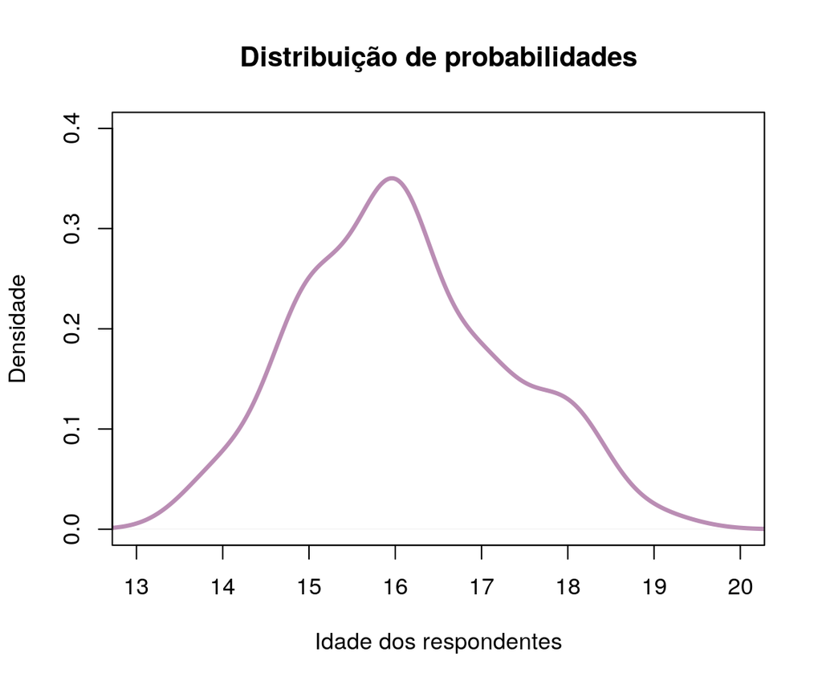

Para descobrir o que são os parâmetros usados e outros mais, comece por

```r
? plot
```

Há um link na documentação que o leva aos parâmetros. É o mesmo que usar

```r
? par
```

O *density plot* mostra uma distribuição unimodal. Define-se a moda, aproximadamente, como a posição do pico da curva de densidade de probabilidades, dada por:

```r
densidade$x[i.mode <- which.max(densidade$y)]
```

```
[1] 15.95835
```

É possível acrescentar linhas ao gráfico. Experimente colocar as de média, mediana e moda, assim:

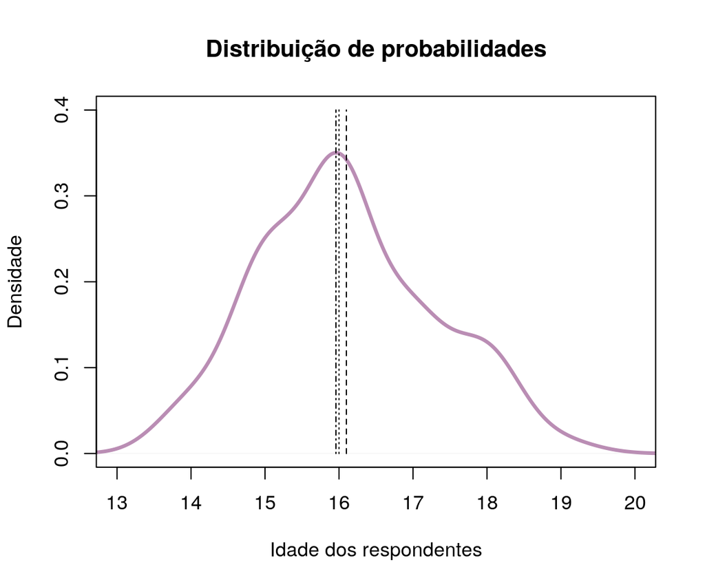

```r
media <- mean(df_metodos$Idade)
mediana <- median(df_metodos$Idade)
densidade <- density(df_metodos$Idade)
moda <- densidade$x[i.mode <- which.max(densidade$y)]
plot(densidade, main="Distribuição de probabilidades", xlab="Idade dos respondentes", xlim=c(13,20), ylab="Densidade", ylim=c(0,0.4), col="#BA8DB4", lwd=3)
lines(x=c(media,media), y=c(0,0.4), lty=2)
lines(x=c(mediana,mediana), y=c(0,0.4), lty=3)
lines(x=c(moda,moda), y=c(0,0.4), lty=4)
```

Quer adicionar uma legenda? Explore a documentação:

```r
? legend
```

Um exemplo (ao meu gosto):

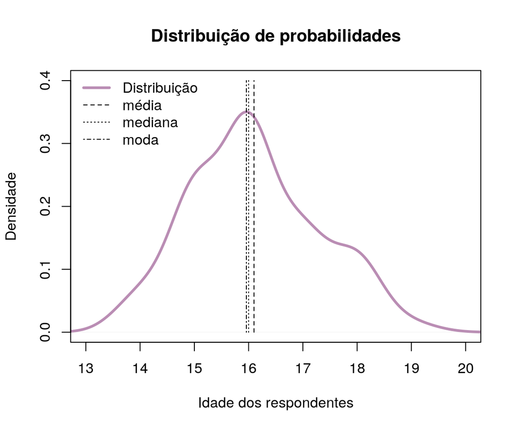

```r
media <- mean(df_metodos$Idade)
mediana <- median(df_metodos$Idade)
densidade <- density(df_metodos$Idade)
moda <- densidade$x[i.mode <- which.max(densidade$y)]
plot(densidade, main="Distribuição de probabilidades", xlab="Idade dos respondentes", xlim=c(13,20), ylab="Densidade", ylim=c(0,0.4), col="#BA8DB4", lwd=3)
lines(x=c(media,media), y=c(0,0.4), lty=2)
lines(x=c(mediana,mediana), y=c(0,0.4), lty=3)
lines(x=c(moda,moda), y=c(0,0.4), lty=4)
legend("topleft",
  c("Distribuição","média", "mediana", "moda"),
  col=c("#BA8DB4","black","black","black"),
  lwd=c(3,1,1,1),
  lty=c(1,2,3,4),
  box.lwd=0, bg="transparent")
```

## Entrada de dados entre-participantes e intra-participantes

Considere o seguinte estudo (baseado em Christine Dancey & John Reidy. *Statistics without Maths for Psychology*. Pearson Education Limited 7 ed., 2017):

> Pesquisadores interessados em saber se os cães facilitam ou não as interações sociais entre os adultos realizaram quatro estudos diferentes em que pesquisadores do sexo masculino e feminino caminharam com e sem cachorros. Em dois estudos, o pesquisador abordou pessoas e pediu algum dinheiro, em outro estudo o pesquisador deixou cair algumas moedas para ver se as pessoas ajudariam a pegá-las e, em um estudo final, um pesquisador do sexo masculino abordou mulheres na rua e pediu-lhes números de telefone. Em cada estudo, o pesquisador realizou as tarefas com e sem cães. Em todos os quatro estudos descobriram que os comportamentos de ajuda eram mais frequentes quando o pesquisador tinha um cachorro.

Os dados são os seguintes:

- Passeando com cão: 9 7 10 12 6 8
- Passeando sem cão: 4 5 3 6 5 1

Para o exercício seguinte, baixe os arquivos cao_entreparticipantes.xlsx e cao_intraparticipantes.xlsx para a pasta do projeto.

### entre-participantes

Suponha que um grupo andou sem os cães, e outro grupo com os cães, definindo-se um estudo entre-participantes. A forma de estruturar este tipo de dado é montar sua planilha em duas colunas, uma para o grupo (com ou sem cão) e outra com o número de encontros.

Como boa prática vamos carregar a planilha, olhar sua estrutura e apresentar as primeiras linhas para vermos se nada estranho aparece.

```r
library(readxl)
dt_cao_entre <- read_excel("cao_entreparticipantes.xlsx")
```

```r
str(dt_cao_entre)
```

```
Classes 'tbl_df', 'tbl' and 'data.frame':   12 obs. of  2 variables:
 $ Cachorro : chr  "com" "com" "com" "com" ...
 $ Encontros: num  9 7 10 12 6 8 4 5 3 6 ...
```

```r
sapply(dt_cao_entre, typeof)
```

```
   Cachorro   Encontros
"character"    "double"
```

```r
dt_cao_entre
```

```
# A tibble: 12 x 2
   Cachorro Encontros
   <chr>        <dbl>
 1 com              9
 2 com              7
 3 com             10
 4 com             12
 5 com              6
 6 com              8
 7 sem              4
 8 sem              5
 9 sem              3
10 sem              6
11 sem              5
12 sem              1
```

Também para termos uma boa ideia dos achados (e ver se não há dados estranhos no arquivo, como aconteceria por erros de digitação), uma estratégia é usar alguma estatística descritiva.

Para ter um sumário descritivo dos dados assim arranjados pode ser:

```r
summary(dt_cao_entre$Encontros)
```

```
   Min. 1st Qu.  Median    Mean 3rd Qu.    Max.
  1.000   4.750   6.000   6.333   8.250  12.000
```

Para separar os encontros com e sem cachorros:

```r
summary(dt_cao_entre$Encontros[dt_cao_entre$Cachorro=="com"])
```

```
   Min. 1st Qu.  Median    Mean 3rd Qu.    Max.
  6.000   7.250   8.500   8.667   9.750  12.000
```

```r
summary(dt_cao_entre$Encontros[dt_cao_entre$Cachorro=="sem"])
```

```
   Min. 1st Qu.  Median    Mean 3rd Qu.    Max.
   1.00    3.25    4.50    4.00    5.00    6.00
```

### intra-participantes

Suponha que as mesmas pessoas andaram sem os cães em um momento e com os cães em outro, definindo-se um estudo intre-participantes. A forma de estruturar este tipo de dado é montar em duas colunas, uma para cada grupo:

```r
library(readxl)
dt_cao_intra <- read_excel("cao_intraparticipantes.xlsx")
```

```r
str(dt_cao_intra)
```

```
Classes 'tbl_df', 'tbl' and 'data.frame':   6 obs. of  2 variables:
 $ Com_cachorro: num  9 7 10 12 6 8
 $ Sem_cachorro: num  4 5 3 6 5 1
```

```r
sapply(dt_cao_intra, typeof)
```

```
Com_cachorro Sem_cachorro
    "double"     "double"
```

```r
dt_cao_intra
```

```
# A tibble: 6 x 2
  Com_cachorro Sem_cachorro
         <dbl>        <dbl>
1            9            4
2            7            5
3           10            3
4           12            6
5            6            5
6            8            1
```

A estrutura é bem diferente da anterior. Este arquivo tem colunas chamadas **Com_cachorro** e **Sem_cachorro**. Cada linha contém um mesmo indivíduo, submetido às duas situações. Os dois tipos de encontro, portanto, já estão separados.

A estratégia para ter um sumário descritivo dos dados assim arranjados precisa ser adaptada. Por exemplo, pode ser:

```r
summary(dt_cao_intra$Com_cachorro)
```

```
   Min. 1st Qu.  Median    Mean 3rd Qu.    Max.
  6.000   7.250   8.500   8.667   9.750  12.000
```

```r
summary(dt_cao_intra$Sem_cachorro)
```

```
   Min. 1st Qu.  Median    Mean 3rd Qu.    Max.
   1.00    3.25    4.50    4.00    5.00    6.00
```

Podemos, também, criar uma coluna adicional (**dt_cao_intra** é um *data frame*) com a diferença entre o número de encontros entre as situações:

```r
dt_cao_intra$Diferenca <- dt_cao_intra$Com_cachorro-dt_cao_intra$Sem_cachorro
summary(dt_cao_intra$Diferenca)
```

```
   Min. 1st Qu.  Median    Mean 3rd Qu.    Max.
  1.000   2.750   5.500   4.667   6.750   7.000
```

Além disto, todos os gráficos discutidos acima podem ser adaptados para melhor descrever os estudos aqui apresentados (tente você mesmo).

## Comentário final

Sugerimos que transforme **R** em sua ferramenta do dia-a-dia.

Esperamos que este tutorial o motive e facilite começar. A linguagem é enorme (há mais de 10 mil funções em *packages* para pegar através da Internet) e crescente (pois todo usuário R pode criar novos pacotes e distribuí-los). Não há somente estatística, embora seja um dos pontos fortes (estatísticos do mundo todo a adotaram), mas há pacotes para outros fins, como geoprocessamento, epidemiologia e lógica fuzzy, para citar uns poucos. Não se perca: a ideia é ir procurando por eles à medida do necessário.

Divirtas-e com **R**!